# MLE in R

Alexander D Forrence

October 12, 2015

```r
library(bbmle)
library(emdbook)
library(ggplot2)
library(psyphy)
library(zoo)

setwd("C:/Users/aforr_000/Desktop/lab-materials/mle")
df <- read.csv("RTSample.csv", col.names = c("RT", "hit"))
head(df)
```

```
##       RT hit
## 1 573.08   0
## 2 525.00   1
## 3 378.85   1
## 4 186.54   1
## 5 517.31   1
## 6 413.46   0
```

```r
# Remove NAs
df <- df[complete.cases(df),]
# Reorder
df <- df[order(df$RT),]
# Filter out impossible
df <- df[df$RT > 0,]
```

We can take the rolling mean, just to get an idea of the data.

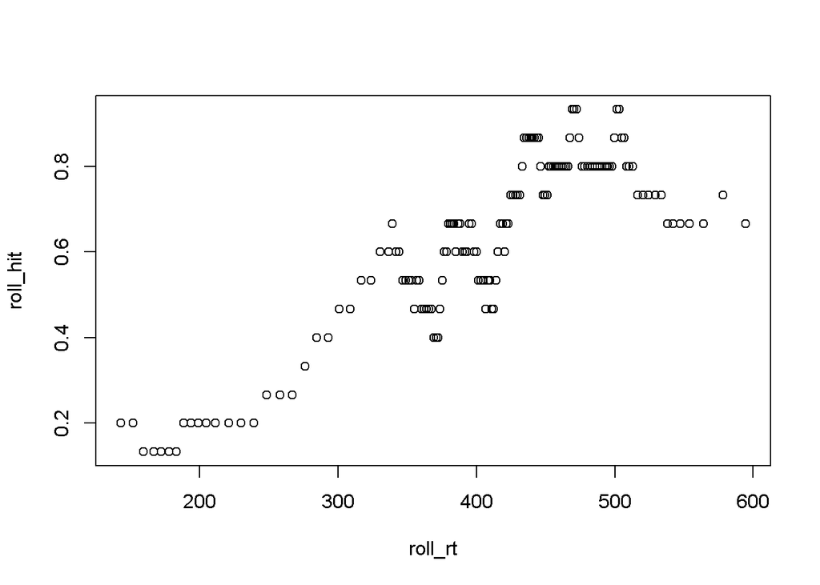

```r
roll_hit <- rollmean(df$hit, 15)
roll_rt <- rollmean(df$RT, 15)
df2 <- data.frame(cbind(roll_rt, roll_hit))
plot(roll_hit ~ roll_rt, data = df2)
```

Now we’ll set the initial estimates, etc…

The MATLAB negative log likelihood function was:

```r
LL = @(params)
    -sum(hit.*log(1/Ntargs+(asymptErr-1/Ntargs)*normcdf(RT,params(1),params(2))) +
             (1-hit).*log(1-(1/Ntargs+(asymptErr-1/Ntargs)*normcdf(RT,params(1),
            params(2))))) - alpha*params(2)^2;
```

```r
logliksig <- function(mu, sigma, ivs, dv){
    alpha <- 0
    Ntargs <- 6
    asymptErr <- 0.7

    phi_ish <- log(1/Ntargs + (asymptErr - 1/Ntargs) *
                       pnorm(ivs, mu, sigma))

    phi_ish2 <- log(1 - (1/Ntargs + (asymptErr - 1/Ntargs) *
                             pnorm(ivs, mu, sigma)))

    -sum(dv %*% phi_ish + (1 - dv) %*% phi_ish2) - alpha * sigma^2
}

# Optimizing
mu <- 200
sigma <- 100

start_vals <- list(mu = mu, sigma = sigma)

# We can even put a bound on sigma (which keeps it from yelling)
m1 <- mle2(logliksig,
           start = start_vals,
           method = "L-BFGS-B",
           optimizer = "optim",
           data = list(ivs = df$RT, dv = df$hit),
           lower = list(sigma = 0))
summary(m1)
```

```
## Maximum likelihood estimation
##
## Call:
## mle2(minuslogl = logliksig, start = start_vals, method = "L-BFGS-B",
##     optimizer = "optim", data = list(ivs = df$RT, dv = df$hit),
##     lower = list(sigma = 0))
##
## Coefficients:
##       Estimate Std. Error z value   Pr(z)
## mu     318.261     32.087  9.9186 < 2e-16 ***
## sigma   64.423     26.632  2.4190 0.01556 *
## ---
## Signif. codes:  0 '***' 0.001 '**' 0.01 '*' 0.05 '.' 0.1 ' ' 1
##
## -2 log L: 187.0785
```

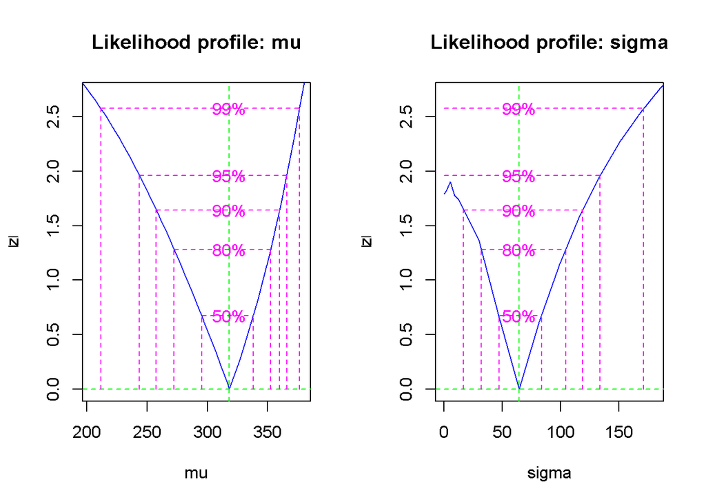

```r
m1_prof <- profile(m1)
plot(m1_prof)
```

The profile function returns the signed square root of the difference between the deviance and the minimum deviance (so that if the profile is perfectly quadratic, lines will be straight) [manual](https://cran.r-project.org/web/packages/bbmle/bbmle.pdf).

We can look at the surface too (not too pretty):

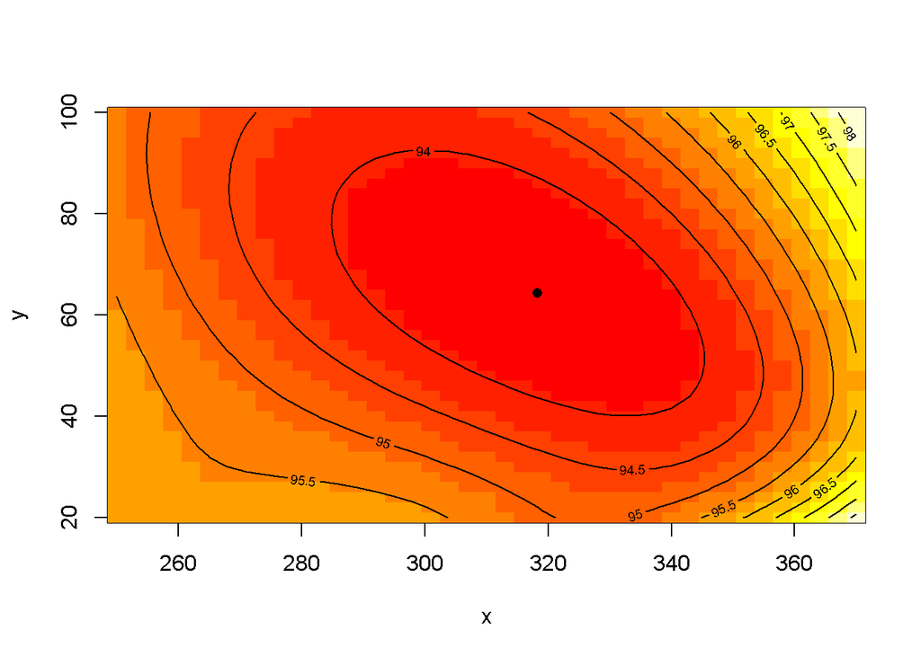

```r
cc <- curve3d(m1@minuslogl(x,y,df$RT,df$hit),
              xlim=c(250,370),ylim=c(20,100),sys3d="image")
contour(cc$x,cc$y,cc$z,add=TRUE)
points(coef(m1)[1], coef(m1)[2],pch=16)
```

We got pretty close to MATLAB’s answers of $\mu = 318.2887$ and $\sigma = 64.3154$. `bbmle` also gives us easy access to profile standard errors/confidence intervals on parameters.

```r
confint(m1)
```

```
##          2.5 %   97.5 %
## mu    243.6074 365.9038
## sigma       NA 133.7268
```

We’ll compare it to a `glm` fit, with appropriate link function…

```r
m2 <- glm(hit ~ RT, data = df,
             family = binomial(link = mafc.probit(.m = 6)))
logLik(m1)
```

```
## 'log Lik.' -93.53924 (df=2)
```

```r
logLik(m2)
```

```
## 'log Lik.' -95.93054 (df=2)
```

That doesn’t do as well as our `mle2` fit. However, `psyphy` can also estimate the upper asymptote with a little effort.

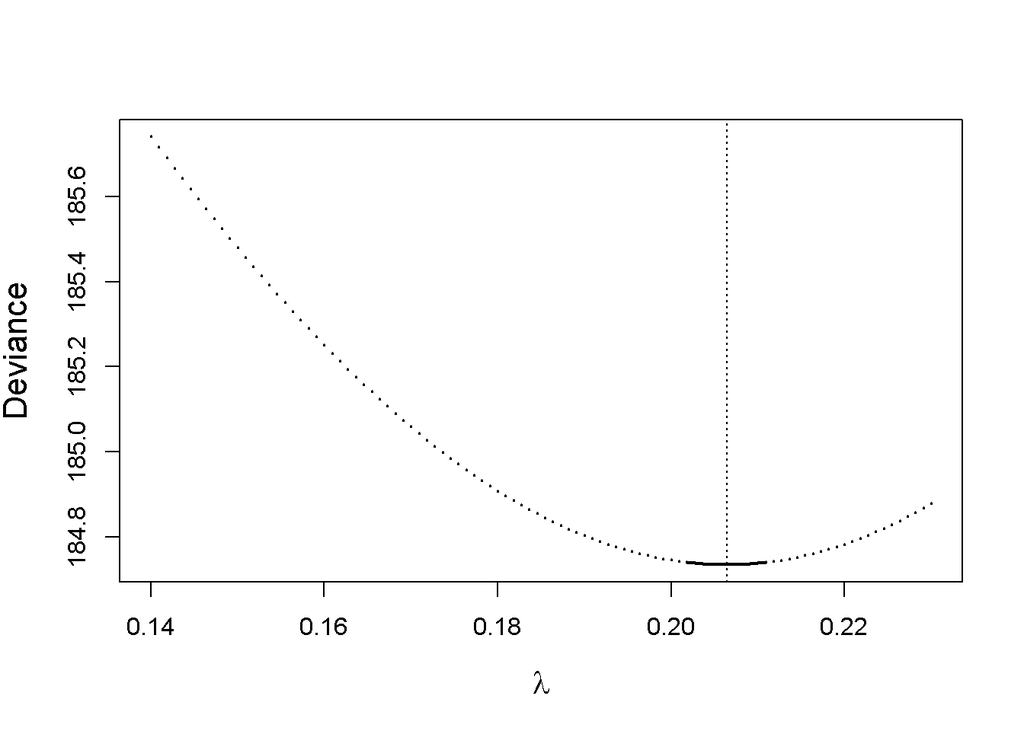

```
##
##  lambda =  0.2064303
```

```r
m3 <- glm.lambda(hit ~ RT,
                 data = df,
                 NumAlt = 6,
                 lambda = seq(0.14, 0.23, len = 100),
                 plot.it = TRUE)
```

```r
summary(m3)
```

```
##
## Call:
## glm(formula = formula, family = binomial(probit.lambda(NumAlt,
##     lmin)), data = data)
##
## Deviance Residuals:
##     Min       1Q   Median       3Q      Max
## -1.7764  -1.0684   0.6987   0.8062   1.8924
##
## Coefficients:
##              Estimate Std. Error z value Pr(>|z|)
## (Intercept) -4.475156   2.215258  -2.020   0.0434 *
## RT           0.013152   0.005881   2.236   0.0253 *
## ---
## Signif. codes:  0 '***' 0.001 '**' 0.01 '*' 0.05 '.' 0.1 ' ' 1
##
## (Dispersion parameter for binomial family taken to be 1)
##
##     Null deviance: 214.53  on 159  degrees of freedom
## Residual deviance: 184.74  on 157  degrees of freedom
## AIC: 188.74
##
## Number of Fisher Scoring iterations: 5
##
## lambda    0.2064
```

```r
logLik(m3)
```

```
## 'log Lik.' -92.36772 (df=2)
```

Which actually gives us a marginally better fit over the ML!

## Predictions

*TODO*: Get predictions using `predict` function from mle2 fit

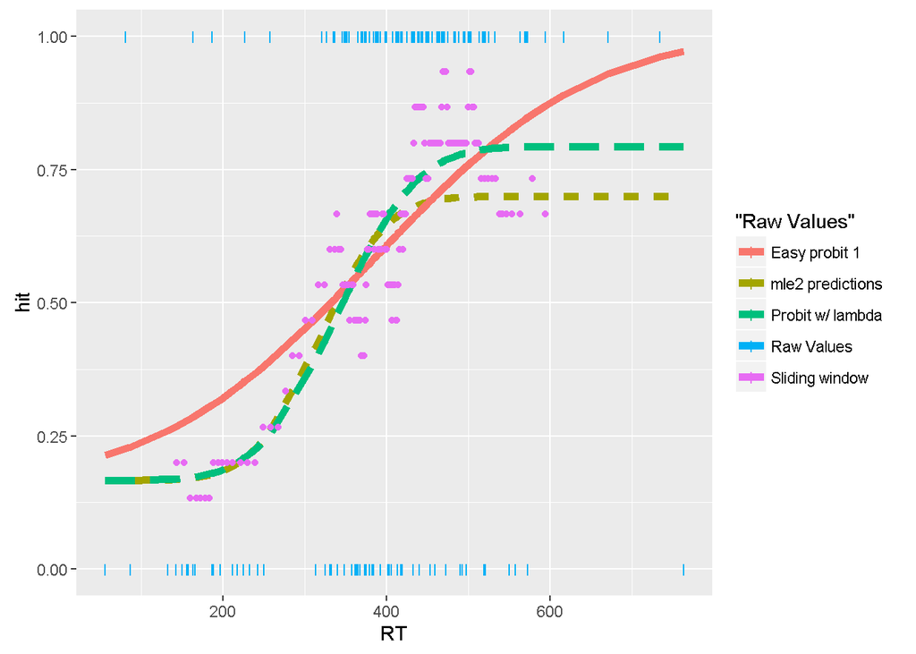

```r
df$pred_m1 <- 1/6 + (.7-1/6) * pnorm(df$RT, coef(m1)[1], coef(m1)[2])
df$pred_m2 <- predict(m2, type = "response")
df$pred_m3 <- predict(m3, type = "response")

ggplot(data = df, aes(x = RT, y = hit)) +
    geom_point(size = 2, shape = 124,
               aes(colour = "Raw Values",
                   linetype = "Raw Values")) +
    geom_line(size = 2,
              aes(y = pred_m1,
                  colour = "mle2 predictions",
                  linetype = "mle2 predictions")) +
    geom_line(size = 2,
              aes(y = pred_m2,
                  colour = "Easy probit 1",
                  linetype = "Easy probit 1")) +
    geom_line(size = 2,
              aes(y = pred_m3,
                  colour = "Probit w/ lambda",
                  linetype = "Probit w/ lambda")) +
    geom_point(data = df2, aes(x = roll_rt, y = roll_hit,
                               colour = "Sliding window"))+
    scale_linetype(guide = FALSE)
```

The probit w/o an asymptote does relatively poorly. The mle estimation could be better, so let’s also maximize over `asymptErr` this time.

```r
logliksig <- function(mu, sigma, asymptErr, ivs, dv){
    alpha <- 0
    Ntargs <- 6

    phi_ish <- log(1/Ntargs + (asymptErr - 1/Ntargs) *
                       pnorm(ivs, mu, sigma))

    phi_ish2 <- log(1 - (1/Ntargs + (asymptErr - 1/Ntargs) *
                             pnorm(ivs, mu, sigma)))

    -sum(dv %*% phi_ish + (1 - dv) %*% phi_ish2) - alpha * sigma^2
}

# Starting values
mu <- 200
sigma <- 100
asymptErr <- 0.7

start_vals <- list(mu = mu, sigma = sigma, asymptErr = asymptErr)

m4 <- mle2(logliksig,
           start = start_vals,
           method = "BFGS",
           optimizer = "optim",
           data = list(ivs = df$RT, dv = df$hit))
summary(m4)
```

```
## Maximum likelihood estimation
##
## Call:
## mle2(minuslogl = logliksig, start = start_vals, method = "BFGS",
##     optimizer = "optim", data = list(ivs = df$RT, dv = df$hit))
##
## Coefficients:
##             Estimate Std. Error z value   Pr(z)
## mu        339.513014  28.414622 11.9485 < 2e-16 ***
## sigma      76.991529  31.606452  2.4359 0.01485 *
## asymptErr   0.793637   0.062909 12.6157 < 2e-16 ***
## ---
## Signif. codes:  0 '***' 0.001 '**' 0.01 '*' 0.05 '.' 0.1 ' ' 1
##
## -2 log L: 184.7367
```

```r
logLik(m4)
```

```
## 'log Lik.' -92.36836 (df=3)
```

```r
logLik(m3)
```

```
## 'log Lik.' -92.36772 (df=2)
```

I removed the bound on `sigma` because the LL was giving infinite values. $\mu = 341.1625$, $\sigma = 76.2185$, $asymptErr = 1.3707$ from MATLAB. The transformed version of asymptErr is ~.7975 (1/(1 + exp(asymptErr))). We also got a slightly better log likelihood compared to MATLAB (93.1552) (are they commensurate though?).

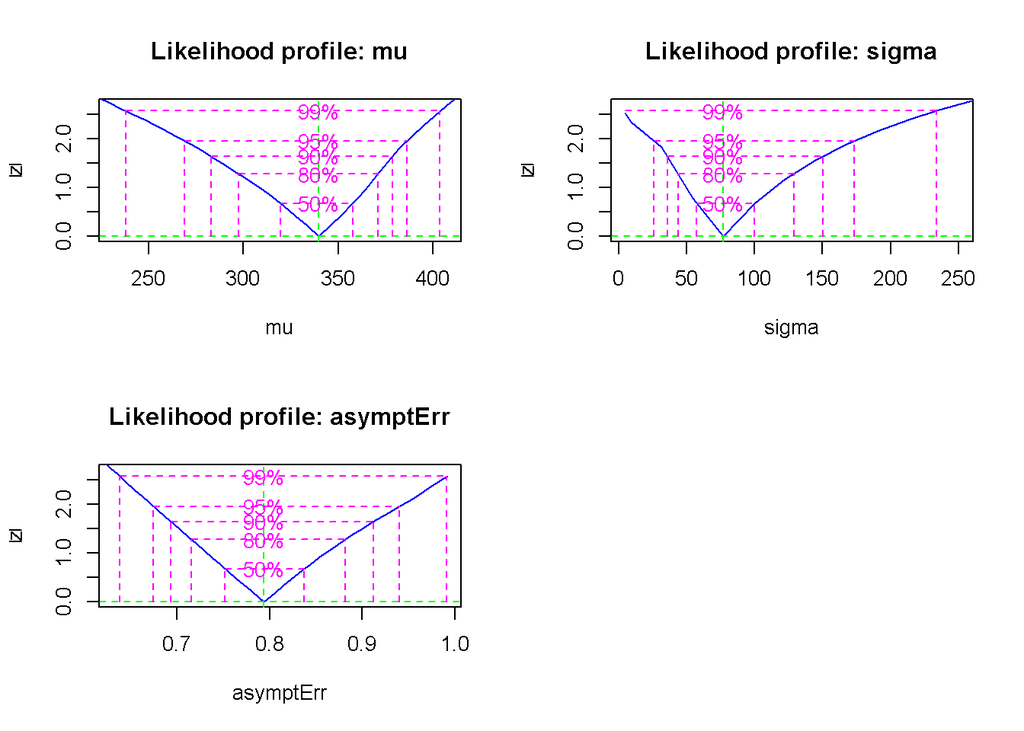

```r
m4_prof <- profile(m4)
plot(m4_prof)
```

```r
confint(m4_prof)
```

```
##                 2.5 %      97.5 %
## mu        268.9826600 386.0977518
## sigma      26.0450804 173.5053989
## asymptErr   0.6742769   0.9404631
```

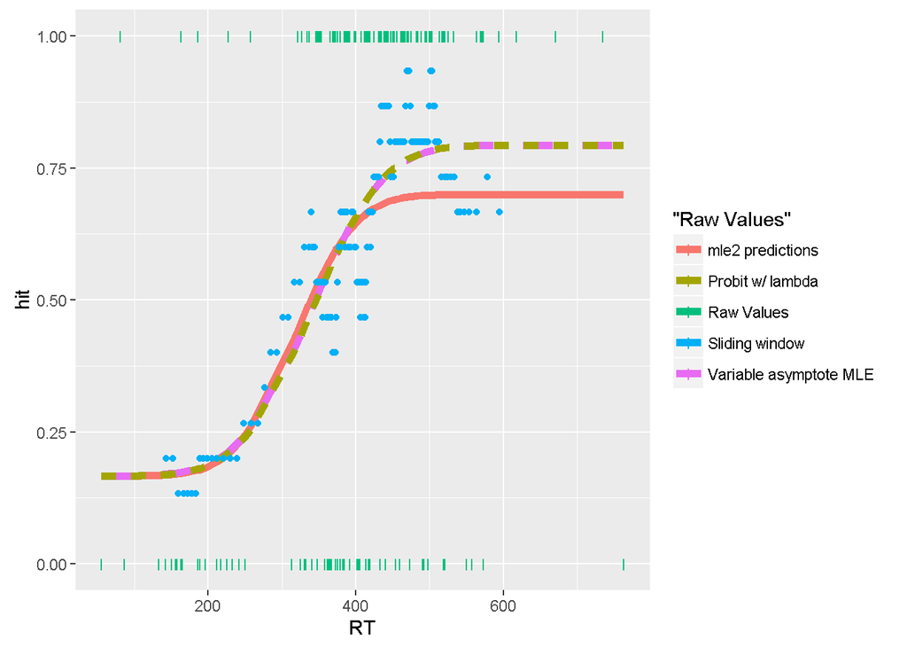

The new mle2 fit and the psyphy fit are practically identical.

One thing that I *just* realized was that the `asymptErr` is equivalent to $(1 - \lambda)$ (and they’re very close in the `m3` & `m4` example). It’s somewhat comforting that we can get the same answer, either by optimizing over the parameter directly or the more kludgy loop.

Other things to try:

- Modeling the population w/ a mixed model
  - See [this discussion](https://stat.ethz.ch/pipermail/r-sig-mixed-models/2013q1/019890.html) for thoughts about optimizing $\lambda$ or `asymptErr` directly (seems pretty difficult though).
- Formula interface to `mle2`, which would give us access to all of the nice things (predictions and such)